# Lab 10.1

## Learning Goals

*At the end of this exercise, you will be able to:*  
1. Review how to make barplots, scatterplots, and boxplots using `ggplot`.  
2. Use aesthetics to improve readability of plots.

## Load the libraries

```r
library("tidyverse")
library("janitor")
```

## Resources

- [ggplot2 cheatsheet](https://rstudio.github.io/cheatsheets/data-visualization.pdf)
- [ggplot themes](https://ggplot2.tidyverse.org/reference/ggtheme.html)
- [Rebecca Barter `ggplot` Tutorial](http://www.rebeccabarter.com/blog/2017-11-17-ggplot2_tutorial/)

## Review

We have already learned the basics of ggplot, but let’s review the plot types we have learned thus far. We will use the mammal life history data to practice. The [data](http://esapubs.org/archive/ecol/E084/093/) are from: *S. K. Morgan Ernest. 2003. Life history characteristics of placental non-volant mammals. Ecology 84:3402.*

```r
life_history <- read_csv("data/mammal_lifehistories_v2.csv", na="-999") %>%
  clean_names()
```

## Bar Plots

Recall that `geom_bar` is used when you want to count the number of observations in a categorical variable. `geom_col` is used when you have already counted the number of observations (or you have a defined x and y) and want to plot those counts.

Make two bar plots showing the number of observations for each order of mammals using both geom types.

`geom_bar`

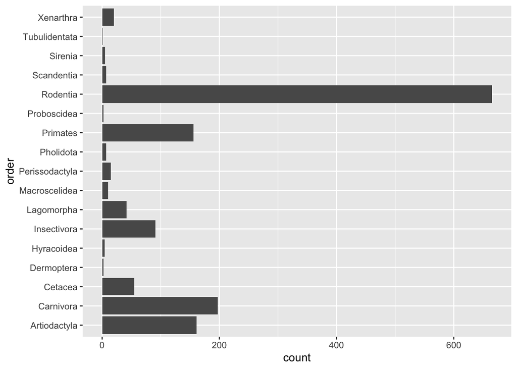

```r
life_history%>%
  ggplot(aes(x=order))+
  geom_bar()+
  coord_flip()
```

`geom_col`

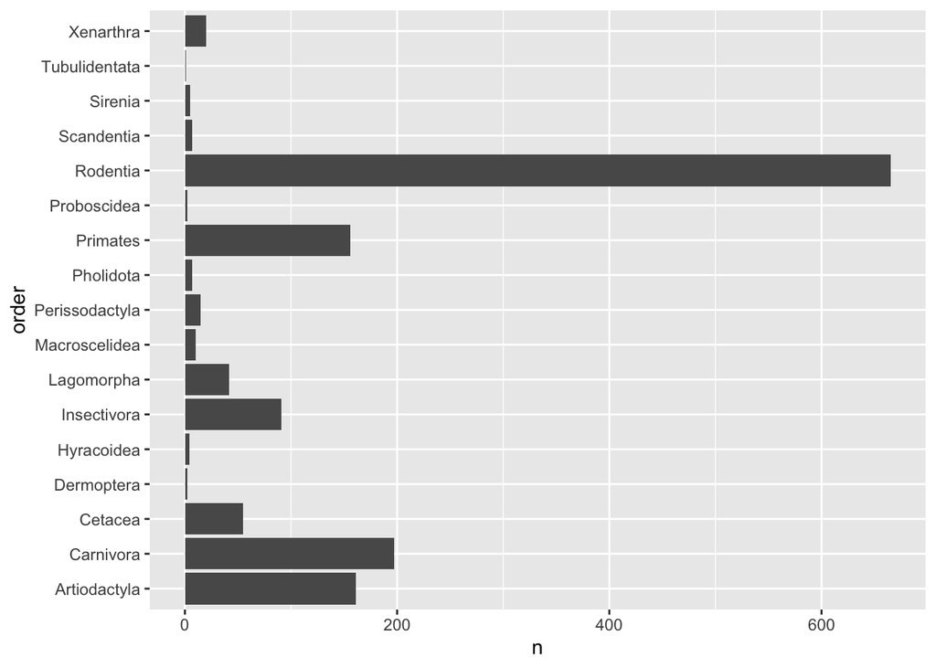

```r
life_history%>%
  count(order, sort=T)%>%
  ggplot(aes(x=order, y=n))+
  geom_col()+
  coord_flip()
```

```r
life_history%>%
  count(order, sort=T)
```

```
## # A tibble: 17 × 2
##    order              n
##    <chr>          <int>
##  1 Rodentia         665
##  2 Carnivora        197
##  3 Artiodactyla     161
##  4 Primates         156
##  5 Insectivora       91
##  6 Cetacea           55
##  7 Lagomorpha        42
##  8 Xenarthra         20
##  9 Perissodactyla    15
## 10 Macroscelidea     10
## 11 Pholidota          7
## 12 Scandentia         7
## 13 Sirenia            5
## 14 Hyracoidea         4
## 15 Dermoptera         2
## 16 Proboscidea        2
## 17 Tubulidentata      1
```

What if we wanted a bar plot of the mean mass for each order?

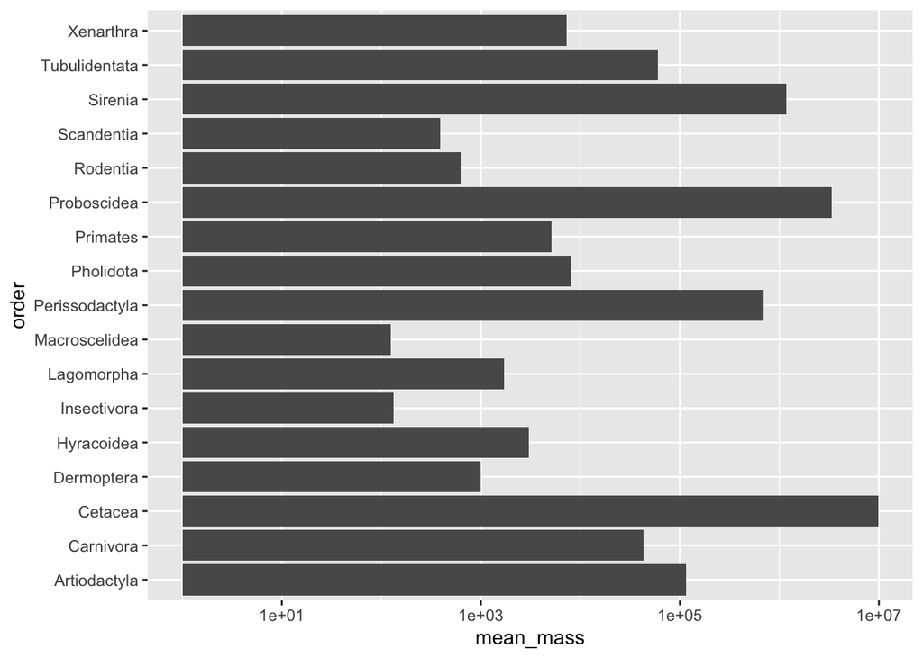

```r
life_history%>%
  group_by(order)%>%
  summarize(mean_mass= mean(mass, na.rm=T))%>%
  arrange(desc(mean_mass))%>%
  ggplot(aes(x=mean_mass, y=order))+
  geom_col()+
  scale_x_log10()
```

```r
options(scipen=999) #cancels scientific notation for the session
```

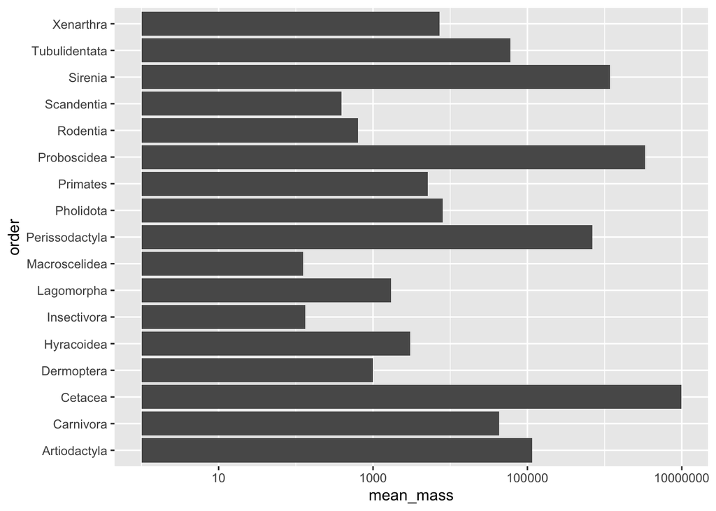

```r
life_history%>%
  group_by(order)%>%
  summarize(mean_mass= mean(mass, na.rm=T))%>%
  arrange(desc(mean_mass))%>%
  ggplot(aes(x=mean_mass, y=order))+
  geom_col()+
  scale_x_log10()
```

Lastly, we can adjust the x-axis labels to make them more readable. We do this using `reorder`.

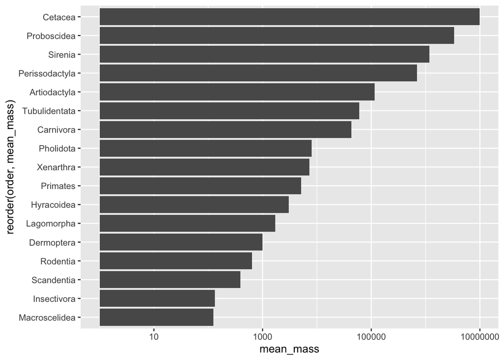

```r
life_history%>%
  group_by(order)%>%
  summarize(mean_mass= mean(mass, na.rm=T))%>%
  arrange(desc(mean_mass))%>%
  ggplot(aes(x=reorder(order, mean_mass), y=mean_mass))+
  coord_flip()+
  geom_col()+
  scale_y_log10()
```

## Scatterplots

Scatter plots allow for comparisons of two continuous variables. Make a scatterplot that compares gestation time and wean mass.

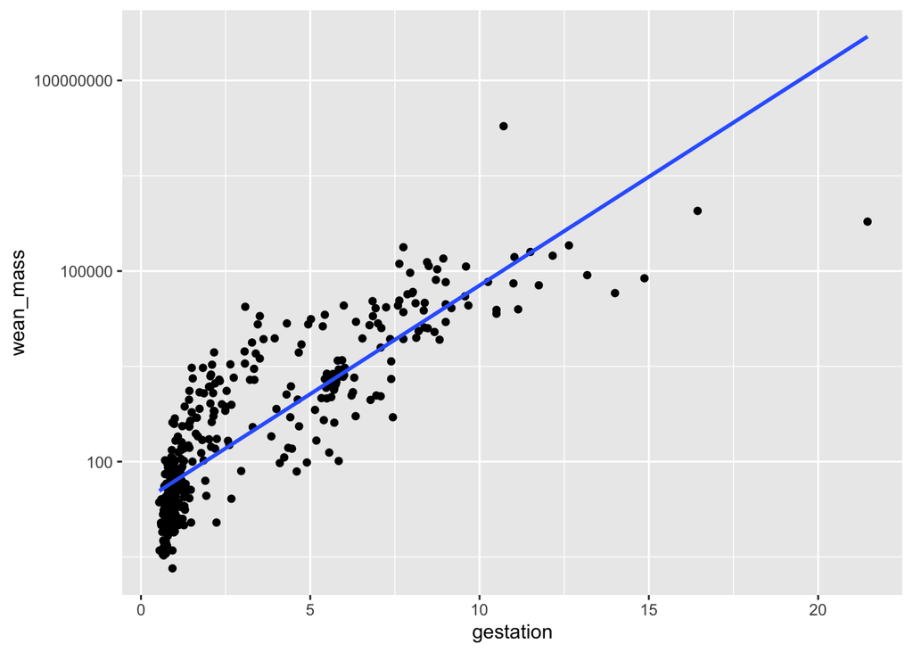

```r
life_history%>%
  group_by(gestation, wean_mass)%>%
  ggplot(aes(x=gestation, y=wean_mass))+
  geom_point(na.rm=T)+
  scale_y_log10()+
  geom_smooth(method = lm, se=F, na.rm=T)
```

## Boxplots

Box plots are used to visualize a range of values. So, on the x-axis we have a categorical variable and the y-axis is the range. Make a box plot that compares mass across orders.

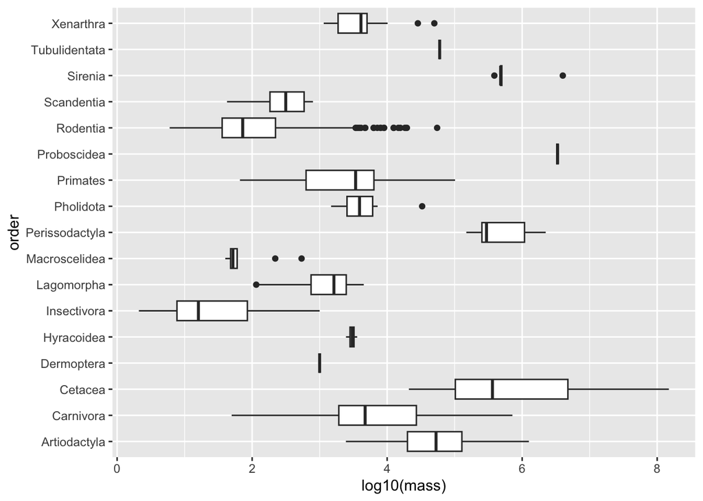

```r
life_history%>%
  #group_by(mass, order)%>%
  ggplot(aes(x=order, y=log10(mass)))+
  geom_boxplot(na.rm = T)+
  coord_flip()
```

## Aesthetics: Labels

Now that we have practiced scatter plots, bar plots, and box plots we need to learn how to adjust their appearance to suit our needs. Let’s start with labeling x and y axes.

Is there a relationship between mass and litter size; i.e. do larger mammals have more offspring?

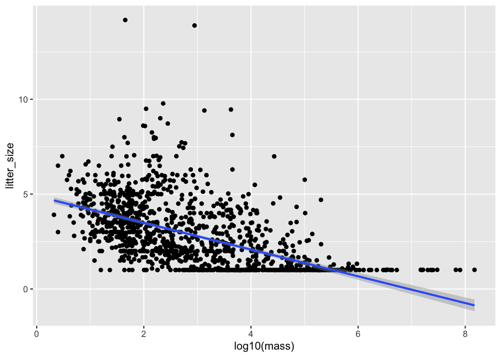

```r
life_history%>%
  ggplot(aes(x=log10(mass), y=litter_size))+
  geom_point()+
  geom_smooth(method = lm)
```

The plot looks clean, but it is incomplete. A reader unfamiliar with the data might have a difficult time interpreting the labels. To add custom labels, we use the `labs` command.

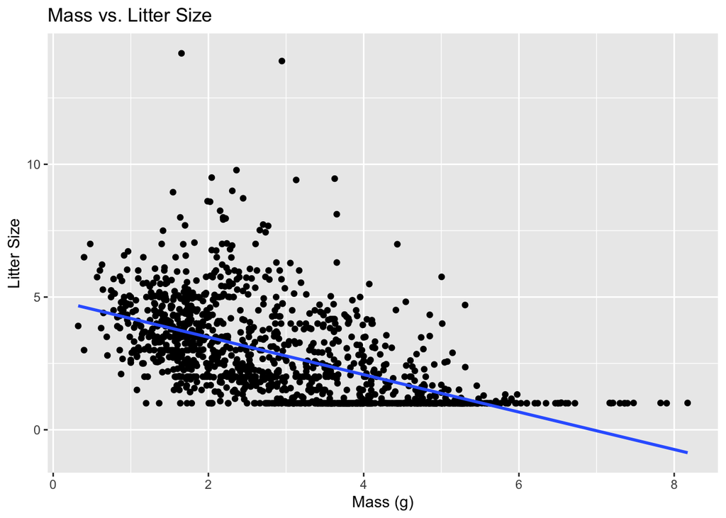

```r
life_history%>%
  ggplot(aes(x=log10(mass), y=litter_size))+
  geom_point()+
  geom_smooth(method = lm, se=F, na.rm=T)+
  labs(title = "Mass vs. Litter Size",
       x="Mass (g)",
       y="Litter Size")
```

We can adjust the plot further by specifying the size and face of the text. We do this using `theme()`. The `rel()` option changes the relative size of the title to keep things consistent. Adding `hjust` controls the title position.

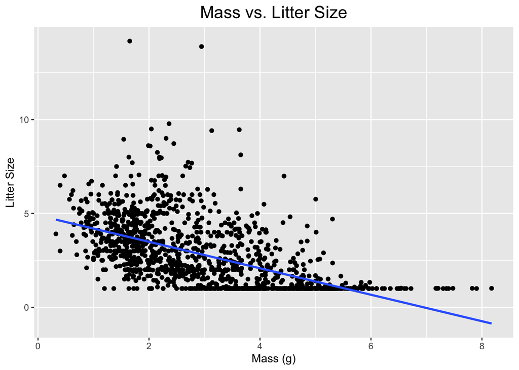

```r
life_history%>%
  ggplot(aes(x=log10(mass), y=litter_size))+
  geom_point()+
  geom_smooth(method = lm, se=F, na.rm=T)+
  labs(title = "Mass vs. Litter Size",
       x="Mass (g)",
       y="Litter Size")+
  theme(plot.title = element_text(size=rel(1.5), hjust = 0.5))
```

## That’s it! Let’s take a break and then move on to part 2!

–>[Home](https://jmledford3115.github.io/datascibiol/)